# IODS course project

## Importing the data ratsL

In this session, we intened to conduct the analysis on the longitudinal dataset ´ratsL´ on which we performed data wrangling:

```
## [1] "X"      "ID"     "Group"  "WD"     "Weight" "Time"
```

```
## 'data.frame':    176 obs. of  6 variables:
##  $ X     : int  1 2 3 4 5 6 7 8 9 10 ...
##  $ ID    : Factor w/ 16 levels "1","2","3","4",..: 1 2 3 4 5 6 7 8 9 10 ...
##  $ Group : Factor w/ 3 levels "1","2","3": 1 1 1 1 1 1 1 1 2 2 ...
##  $ WD    : Factor w/ 11 levels "WD1","WD15","WD22",..: 1 1 1 1 1 1 1 1 1 1 ...
##  $ Weight: int  240 225 245 260 255 260 275 245 410 405 ...
##  $ Time  : int  1 1 1 1 1 1 1 1 1 1 ...
```

```
##        X                ID      Group        WD         Weight
##  Min.   :  1.00   1      : 11   1:88   WD1    :16   Min.   :225.0
##  1st Qu.: 44.75   2      : 11   2:44   WD15   :16   1st Qu.:267.0
##  Median : 88.50   3      : 11   3:44   WD22   :16   Median :344.5
##  Mean   : 88.50   4      : 11          WD29   :16   Mean   :384.5
##  3rd Qu.:132.25   5      : 11          WD36   :16   3rd Qu.:511.2
##  Max.   :176.00   6      : 11          WD43   :16   Max.   :628.0
##                   (Other):110          (Other):80
##       Time
##  Min.   : 1.00
##  1st Qu.:15.00
##  Median :36.00
##  Mean   :33.55
##  3rd Qu.:50.00
##  Max.   :64.00
##
```

#### Graphical display of dataset ratsL

In the corresponding experiment, three groups of rats were put on three different diets. Over a period of 9 weeks, the weight of each rat was measured weekly in grams. Here, we can see the graphical display of the changes of weights of rats of different groups over the measurement time.

#### Figure 8.1

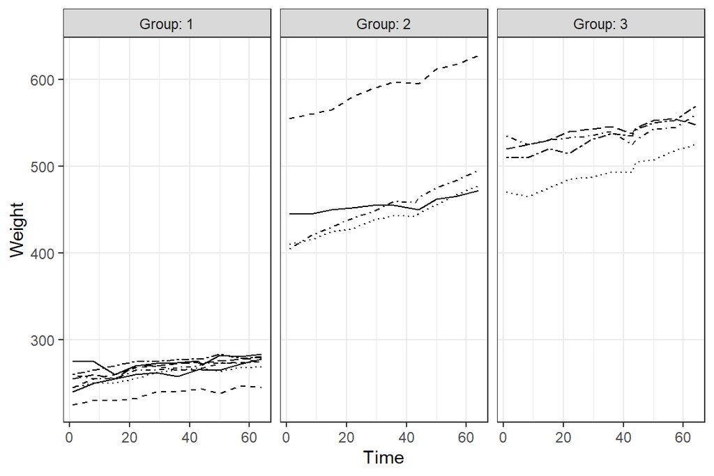

```
## Observations: 33
## Variables: 4
## $ Group <fct> 1, 1, 1, 1, 1, 1, 1, 1, 1, 1, 1, 2, 2, 2, 2, 2, 2, 2, 2,...
## $ WD    <fct> WD1, WD15, WD22, WD29, WD36, WD43, WD44, WD50, WD57, WD6...
## $ mean  <dbl> 250.625, 254.375, 261.875, 264.625, 265.000, 267.375, 26...
## $ se    <dbl> 4.589478, 3.460116, 4.100800, 3.333956, 3.552939, 3.3026...
```

#### Figure 8.3

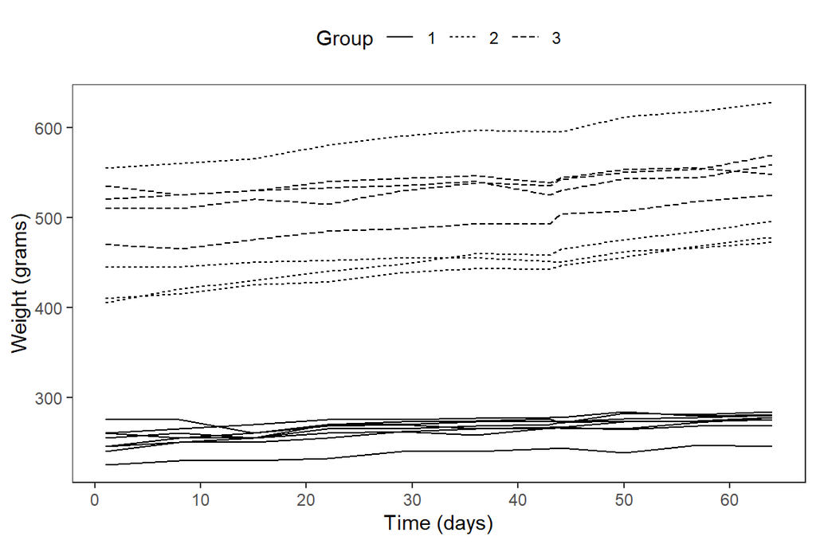

#### Figure 8.4

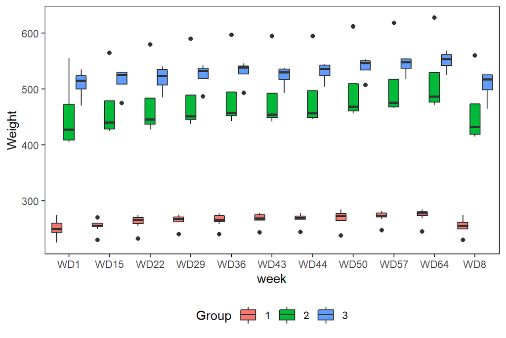

```r
p1 <- ggplot(ratsL, aes(x = factor(WD), y = Weight, fill = Group))
p2 <- p1 + geom_boxplot(position = position_dodge(width = 0.9))
p3 <- p2 + theme_bw() + theme(panel.grid.major = element_blank(), panel.grid.minor = element_blank())
p4 <- p3 + theme(legend.position = "bottom")
p5 <- p4 + scale_x_discrete(name = "week")
# Black & White version:
#p6 <- p5 + scale_fill_grey(start = 0.5, end = 1)
p5
```

#### Figure 8.5

```
## Observations: 16
## Variables: 3
## Groups: Group [3]
## $ Group <fct> 1, 1, 1, 1, 1, 1, 1, 1, 2, 2, 2, 2, 3, 3, 3, 3
## $ ID    <fct> 1, 2, 3, 4, 5, 6, 7, 8, 9, 10, 11, 12, 13, 14, 15, 16
## $ meanW <dbl> 261.0909, 237.6364, 260.1818, 266.5455, 269.4545, 274.72...
```

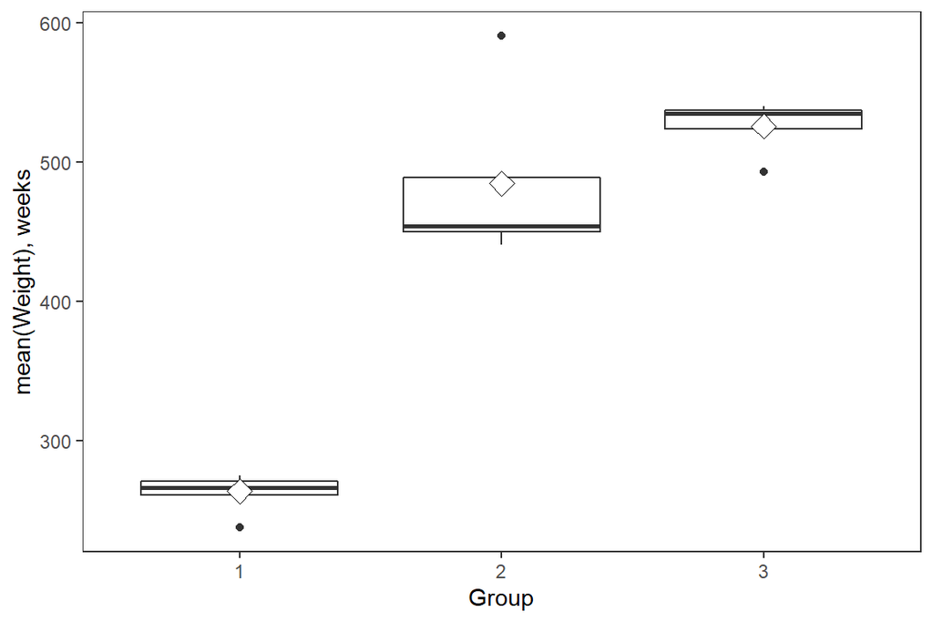

#### Figure 8.6

```
## Observations: 14
## Variables: 3
## Groups: Group [3]
## $ Group <fct> 1, 1, 1, 1, 1, 1, 1, 2, 2, 2, 3, 3, 3, 3
## $ ID    <fct> 1, 3, 4, 5, 6, 7, 8, 9, 10, 11, 13, 14, 15, 16
## $ meanW <dbl> 261.0909, 260.1818, 266.5455, 269.4545, 274.7273, 274.63...
```

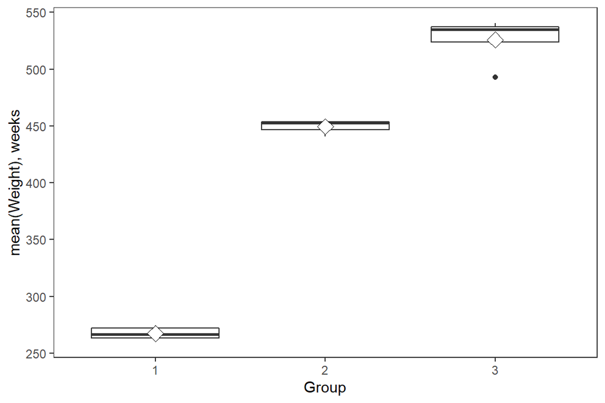

## Table 8.3

```
##             Df Sum Sq Mean Sq F value   Pr(>F)
## Group        2 188182   94091   580.4 7.07e-12 ***
## Residuals   11   1783     162
## ---
## Signif. codes:  0 '***' 0.001 '**' 0.01 '*' 0.05 '.' 0.1 ' ' 1
```

[output not shown]

[output not shown]

[output not shown]